# Smouldering fire in upland swamp soils

## Smouldering fire

```r
library(ggplot2)
library(dplyr)
library(DHARMa)
library(emmeans)
library(parameters)
library(table1)
library(MuMIn)
```

Load data

```r
datadir <- "../data"
locations<- read.csv(file.path(datadir, "Sod_locations.csv"))
smouldering <-read.csv(file.path(datadir, "TM5_Complete_Sod_Data_main.csv"))
```

Clean data and tabulate

```r
som_gravmoist <- smouldering %>%
  filter(!Sample=='MH CH 19') %>%
  left_join(locations) %>%
  mutate(swamp = substr(Sample,1, 3),
         veg = trimws(substr(Sample,4, 6)),
         bd_mg_per_cm3 = bd_g_per_cm3*1000, #mg
         bd_mg_cat = cut(bd_mg_per_cm3, breaks = c(0,250, 400, 2000)),
         bd_mg_cat = factor(bd_mg_cat, labels = c(200,300,500))) %>%
    dplyr::select(binomial_burn_status, grav_moist_percent , som_percent, bd_mg_per_cm3, swamp, veg, lat, long, bd_mg_cat)
table1(~grav_moist_percent + som_percent+ bd_mg_per_cm3 |binomial_burn_status, data = som_gravmoist)
```

|  | 0 (N=74) | 1 (N=37) | Overall (N=111) |
| --- | --- | --- | --- |
| grav_moist_percent |  |  |  |
| Mean (SD) | 246 (155) | 24.8 (16.2) | 172 (164) |
| Median [Min, Max] | 218 [16.3, 569] | 21.3 [0.738, 64.4] | 118 [0.738, 569] |
| som_percent |  |  |  |
| Mean (SD) | 40.6 (18.8) | 46.5 (21.5) | 42.6 (19.8) |
| Median [Min, Max] | 40.5 [4.11, 79.4] | 45.5 [2.29, 92.3] | 41.1 [2.29, 92.3] |
| bd_mg_per_cm3 |  |  |  |
| Mean (SD) | 332 (205) | 293 (123) | 319 (182) |
| Median [Min, Max] | 250 [109, 1250] | 271 [131, 609] | 254 [109, 1250] |

### Explore

Plot against burning status.

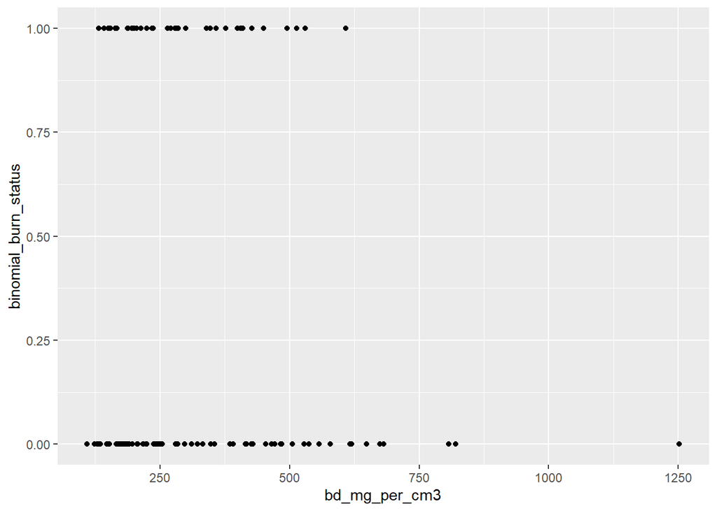

```r
ggplot(som_gravmoist, aes(bd_mg_per_cm3, binomial_burn_status))+
  geom_point()
```

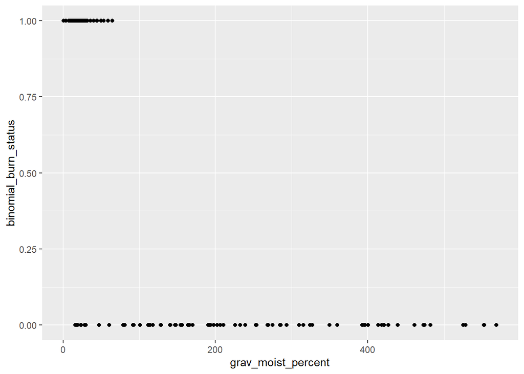

```r
ggplot(som_gravmoist, aes(grav_moist_percent, binomial_burn_status))+
  geom_point()
```

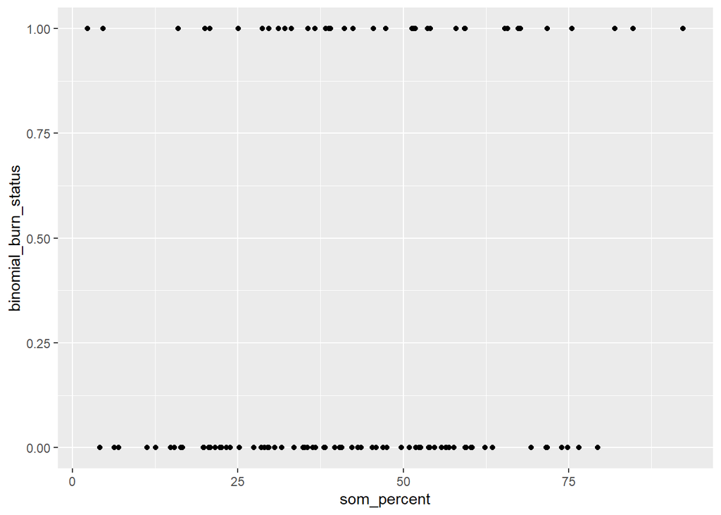

```r
ggplot(som_gravmoist, aes(som_percent, binomial_burn_status))+
  geom_point()
```

We expect grav_moist_percent will be strongest predictor.

### Variable selection, forward stepwise

We do this manually rather than using `stepAIC` as we were getting warnings and wanted to know where they were coming from. We changed from used `AIC` to `AICc` due to reviewer comments, it made no difference to the model chosen.

```r
cor(som_gravmoist[,c(2,3,4)])
```

```
##                    grav_moist_percent som_percent bd_mg_per_cm3
## grav_moist_percent          1.0000000   0.2871536    -0.4664196
## som_percent                 0.2871536   1.0000000    -0.7340535
## bd_mg_per_cm3              -0.4664196  -0.7340535     1.0000000
```

The largest correlation is 0.73 so we aren’t worried about multicollinearity.

Models with one predictor:

```r
base_mod_smould <- glm(binomial_burn_status ~1, family=binomial, data = som_gravmoist)
base_mod_smould_grav <- glm(binomial_burn_status ~  + grav_moist_percent, family=binomial, data = som_gravmoist)
base_mod_smould_som <- glm(binomial_burn_status ~  +som_percent, family=binomial, data = som_gravmoist)
base_mod_smould_bd <- glm(binomial_burn_status ~  + bd_mg_per_cm3, family=binomial, data = som_gravmoist)

AICc(base_mod_smould, base_mod_smould_grav, base_mod_smould_som, base_mod_smould_bd)
```

|  | df | AICc |
| --- | --- | --- |
| base_mod_smould | 1 | 143.34284 |
| base_mod_smould_grav | 2 | 53.59974 |
| base_mod_smould_som | 2 | 143.22612 |
| base_mod_smould_bd | 2 | 144.19159 |

grav_moist_percent is best of these models. We keep adding variables

```r
base_mod_smould_grav_som <- glm(binomial_burn_status ~  grav_moist_percent + som_percent, family=binomial, data = som_gravmoist)
base_mod_smould_grav_bd <- glm(binomial_burn_status ~  grav_moist_percent + bd_mg_per_cm3, family=binomial, data = som_gravmoist)
AICc(base_mod_smould_grav, base_mod_smould_grav_som, base_mod_smould_grav_bd)
```

|  | df | AICc |
| --- | --- | --- |
| base_mod_smould_grav | 2 | 53.59974 |
| base_mod_smould_grav_som | 3 | 42.24956 |
| base_mod_smould_grav_bd | 3 | 26.45717 |

Lowest AIC includes grav and bd, so we keep going to see if som improves model.

```r
base_mod_smould_grav_bd_som <- glm(binomial_burn_status ~  grav_moist_percent  +bd_mg_per_cm3+som_percent, family=binomial, data = som_gravmoist)
AICc(base_mod_smould_grav_bd, base_mod_smould_grav_bd_som)
```

|  | df | AICc |
| --- | --- | --- |
| base_mod_smould_grav_bd | 3 | 26.45717 |
| base_mod_smould_grav_bd_som | 4 | 28.41467 |

Lowest AIC is grav and bd only.

Check assumptions

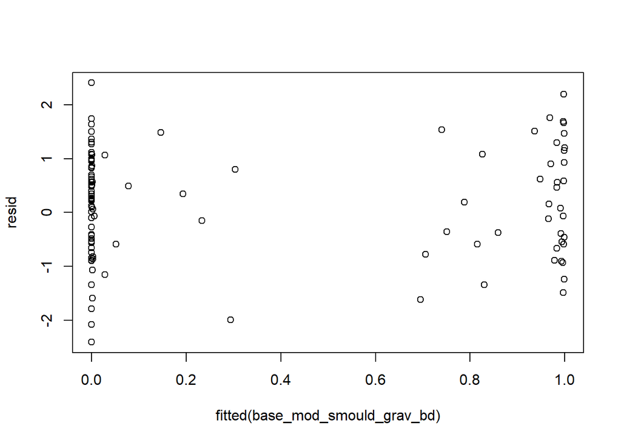

```r
sim= simulateResiduals(base_mod_smould_grav_bd)
resid = residuals(sim, quantileFunction = qnorm, outlierValues = c(-7,7))
plot(resid~fitted(base_mod_smould_grav_bd))
```

Residuals are okay.

The model has warnings about ‘fitted probabilities numerically 0 or 1 occurred’, this is often perfect separation. We look at standard errors of coefficients.

```r
summary(base_mod_smould_grav_bd_som)
```

```
##
## Call:
## glm(formula = binomial_burn_status ~ grav_moist_percent + bd_mg_per_cm3 +
##     som_percent, family = binomial, data = som_gravmoist)
##
## Coefficients:
##                     Estimate Std. Error z value Pr(>|z|)
## (Intercept)        12.135380   4.498823   2.697  0.00699 **
## grav_moist_percent -0.082409   0.027861  -2.958  0.00310 **
## bd_mg_per_cm3      -0.017333   0.006438  -2.692  0.00709 **
## som_percent        -0.021843   0.051072  -0.428  0.66887
## ---
## Signif. codes:  0 '***' 0.001 '**' 0.01 '*' 0.05 '.' 0.1 ' ' 1
##
## (Dispersion parameter for binomial family taken to be 1)
##
##     Null deviance: 141.306  on 110  degrees of freedom
## Residual deviance:  20.037  on 107  degrees of freedom
## AIC: 28.037
##
## Number of Fisher Scoring iterations: 10
```

Standard errors are reasonable. For large values of grav, the probability of burning is appropriately very near 0 (see plots below), so we don’t believe there is perfect separation.

### Inference

Calculate odds ratios.

```r
parameters(base_mod_smould_grav_bd, exponentiate = T, ci_method  = "profile", digits = 4)
```

| Parameter | Coefficient | SE | CI | CI_low | CI_high | z | df_error | p |
| --- | --- | --- | --- | --- | --- | --- | --- | --- |
| (Intercept) | 5.187123e+04 | 1.661835e+05 | 0.95 | 448.7015336 | 2.206911e+08 | 3.388670 | Inf | 0.0007023235 |
| grav_moist_percent | 9.180643e-01 | 2.634731e-02 | 0.95 | 0.8485278 | 9.565235e-01 | -2.978800 | Inf | 0.0028937942 |
| bd_mg_per_cm3 | 9.843546e-01 | 5.075940e-03 | 0.95 | 0.9712802 | 9.921721e-01 | -3.058025 | Inf | 0.0022280122 |

Calculate predictions

```r
ems_full_smould = emmip(base_mod_smould_grav_bd, ~ grav_moist_percent +  bd_mg_per_cm3, type = "response",  CIs = TRUE,
      at = list(grav_moist_percent = seq(0,500,by=5),
                bd_mg_per_cm3 = c(200, 300, 500)), plotit = FALSE)

ems_full_smould$bd_mg_cat <- ems_full_smould$bd_mg_per_cm3

ems_full_smould$bd_mg_per_cm3 = factor(ems_full_smould$bd_mg_per_cm3)
write.csv(ems_full_smould,file="../results/pred_smould.csv")

ems_full_smould %>%
  filter(grav_moist_percent %in% c(50, 100, 150)) %>%
  transmute(grav_moist_percent,
            bd_mg_per_cm3,
            pred_burn_prob = round(yvar, 4),
            LCL = round(LCL, 4),
            UCL = round(UCL,4))
```

| grav_moist_percent | bd_mg_per_cm3 | pred_burn_prob | LCL | UCL |
| --- | --- | --- | --- | --- |
| 50 | 200 | 0.9686 | 0.7391 | 0.9970 |
| 100 | 200 | 0.3003 | 0.0256 | 0.8751 |
| 150 | 200 | 0.0059 | 0.0000 | 0.4879 |
| 50 | 300 | 0.8643 | 0.5610 | 0.9695 |
| 100 | 300 | 0.0814 | 0.0048 | 0.6212 |
| 150 | 300 | 0.0012 | 0.0000 | 0.2322 |
| 50 | 500 | 0.2138 | 0.0534 | 0.5673 |
| 100 | 500 | 0.0038 | 0.0001 | 0.1724 |
| 150 | 500 | 0.0001 | 0.0000 | 0.0428 |

Plot.

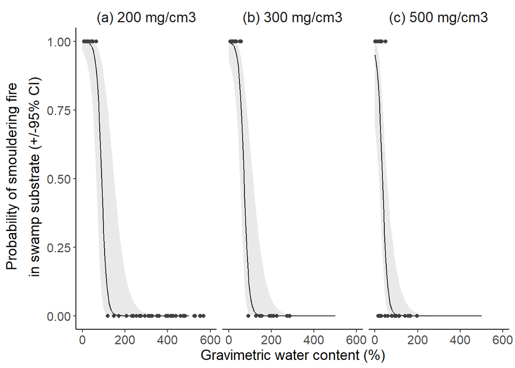

```r
#modify facet labels
bd_names <- as_labeller(
  c('200' = "(a) 200 mg/cm3", '300' = "(b) 300 mg/cm3", '500' = "(c) 500 mg/cm3"))


smould_plot <- ggplot(ems_full_smould, aes(grav_moist_percent, yvar)) +
  geom_ribbon(aes(ymin = LCL, ymax = UCL), alpha = 0.5, fill = "lightgrey")+
  geom_line()+
  geom_point(colour = "grey25", data = som_gravmoist, aes(grav_moist_percent,binomial_burn_status)) +
  xlab("Gravimetric water content (%)")+
  ylab(expression(atop(paste("Probability of smouldering fire"), paste("in swamp substrate (+/-95% CI)"))))+
  theme(axis.text = element_text(size = 12))+
  theme(axis.title = element_text(size = 14), strip.background = element_rect(colour="white", fill="white"))+
  theme(plot.title = element_text(size = 14))+
  theme(strip.text = element_text(size = 14))+
  theme(legend.text = element_text(size = 12))+
  xlim(0,600)+
  facet_grid(~bd_mg_cat, labeller = bd_names)+
    theme(panel.grid.major = element_blank(), panel.grid.minor = element_blank(),
        panel.background = element_blank(), axis.line = element_line(colour = "black"))
smould_plot
```

```r
ggsave(plot = smould_plot, file = "../results/smould_plot.tiff" , width = 180, height = 100, units = "mm", device = "tiff")
```

Note : The plots contain data from 0-250, 250-400, 400-max but predictions at 200, 300 and 500